# Actuary and Data-Science Study Case

Yu TANG

8 juillet 2017

# 1 Summary

The problem we are trying to solve here is to build models to predict expected annual profit per customer on an automobile insurance contract, with a high degree of predictive accuracy. The problem does not call for specific algorithms or techniques to be used. The error evaluation is based on Root-Mean-Squared-Error (RMSE) between the predicted value and the observed profit.

In this project, we perform the following tasks :

First of all, we identify the missing records in the datasets and study the relationship between the target variable (Profit) and explicative variables graphically.

Next, we apply 7 different machine learning algorithms to predit the profit, including :

- 1 Linear Regression Model
- 2 Classification Tree Model
- 3 Neural Net Model
- 4 GLM Model
- 5 Random Forest Model
- 6 Xgboost Model
- 7 Generalized Boosted Regression Model

Then, we apply arithmetic/geometric means from multiple models to increase accuracy. For each method, we evaluate the error rate by RMSE. At last, we compare the results obtained from different models and apply the best model to the test set.

The results show that, among all models tested, the best 2 models for our study case are Random Forest Model and Generalized Boosted Regression Model. The model which combines Random Forest Model and Xgboost Model gives better prediction than any of both individual models, but still not competitive with Generalized Boosted Regression Model.

# 2 Data

## 2.1 Load the files and check for missing values

First we load the data sets and look at which columns are categorical, unique level in each column and the number of missing values in each column. Since the number of missing values is not significant, we exclude them from the training data set.

```r
# read data
train <- read.csv(file = "/Users/yuyu/Desktop/Study_Case/labeled_dataset.csv", header =
                     TRUE, sep = ",")
test <- read.csv(file = "/Users/yuyu/Desktop/Study_Case/scoring_dataset.csv", header =
                          TRUE, sep = ",")
```

```r
#Data Cleansing
row.has.na <- apply(train, 1, function(x) {
  any(is.na(x))
})
train <- train[!row.has.na, ][2:14]
```

Check the missing values again.

```r
df.init = data.frame(
  Levels = sapply(train, function(x)
    (length(unique(x)))),
  Categorical = sapply(train, is.factor),
  Missing = sapply(train, function(x)
    (sum(is.na(x))))
)
kable(df.init, output = FALSE)
```

|  | Levels | Categorical | Missing |
| --- | --- | --- | --- |
| Age | 72 | FALSE | 0 |
| Prime.mensuelle | 65 | FALSE | 0 |
| Categorie.socio.professionnelle | 5 | TRUE | 0 |
| Kilometres.parcourus.par.mois | 564 | FALSE | 0 |
| Coefficient.bonus.malus | 84 | FALSE | 0 |
| Type.de.vehicule | 4 | TRUE | 0 |
| Score.CRM | 107 | FALSE | 0 |
| Niveau.de.vie | 913 | FALSE | 0 |
| Marque | 7 | TRUE | 0 |
| Salaire.annuel | 894 | FALSE | 0 |
| Score.credit | 624 | FALSE | 0 |
| Cout.entretien.annuel | 369 | FALSE | 0 |
| Benefice.net.annuel | 972 | FALSE | 0 |

The training and test sets are created for modelling and evaluation.

```r
set.seed(270)
seq_index = sample(seq_len(nrow(train)), size = 100)
train_set = train[-seq_index,]
valid_set = train[seq_index,]
rm(seq_index)
```

## 2.2 Exploratory Data Analysis

We notice that there is a correlation between the type of car and the profit. The more the car is paramount, the more profit we gain from the customer.

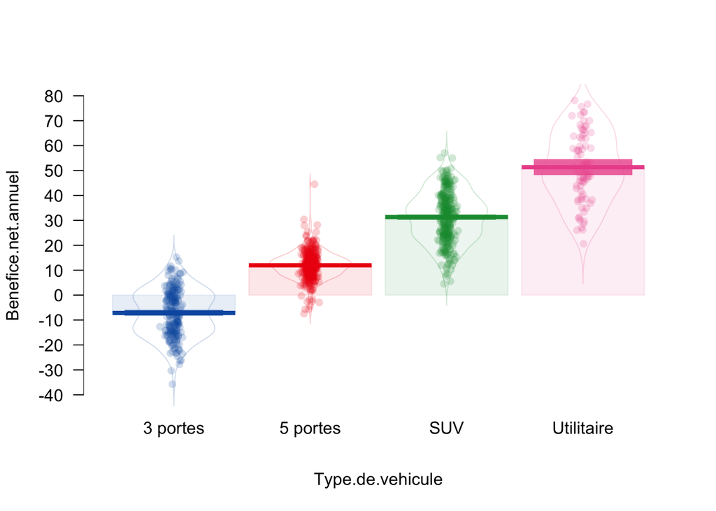

From the figure below, we can tell that “Kilometres.parcourus.par.mois” is another significant variable. Clearly, the more the car is paramount and the more it travels, the more profit we gain. Also, the loss is mainly from cars of 3 doors. The more this type of car travel, the more we lose.

[interactive chart not shown]

# 3 Apply Algorithms

## 3.1 Model 1 - Linear Regression Model

```r
# Model 1 - LINEAR REGRESSION MODEL
lm.fit <- lm(Benefice.net.annuel ~. , data = train_set)
#summary(lm.fit)
# validation of model and error rates
fitmodel = data.frame(predict(lm.fit, valid_set, interval = "prediction"))
```

We create a function based on RMSE to evaluate each model.

```r
validation <- function(premodel){
  xdf = data.frame( Benefice_pred = premodel, Benefice = valid_set$Benefice.net.annuel)
  xdf$RMSE=(xdf$Benefice_pred-xdf$Benefice)^2
  return(c(RMSE=sqrt(mean(xdf$RMSE))))
}
lm.vad <-fitmodel$fit
validation(lm.vad)
```

```
## RMSE
## 7.04
```

## 3.2 Model 2 - Classification Tree Model

[figure not shown]

```r
# Model 2 - CLASSIFICATION TREE MODELS
tree.fit=rpart(Benefice.net.annuel ~ .,data=train_set)
fancyRpartPlot(tree.fit)
```

```r
#summary(tree.fit)
# predict for validation dataset
tree.vad <- predict(tree.fit, valid_set)
validation(tree.vad)
```

```
## RMSE
## 6.04
```

## 3.3 Model 3 - Neural Net Model

```r
# Model 3 - NEURAL NET MODEL
library("nnet")
nnet.fit = nnet(Benefice.net.annuel ~.,
                  data = train_set, size = 3, skip = TRUE, linout = TRUE)
# predict for validation dataset
nnet.vad <- predict(nnet.fit, valid_set)
validation(nnet.vad)
```

```
## RMSE
## 7.04
```

## 3.4 Model 4 - GLM Model

```r
# Model 4 - GLM MODEL
glm.fit <- glm(Benefice.net.annuel ~., data = train_set)
#summary(glm.fit)
# validate model:
glm.vad = predict(glm.fit, valid_set)
validation(glm.vad)
```

```
## RMSE
## 7.04
```

## 3.5 Model 5 - Random Forest Model

```r
# Model 5 - RANDOM FOREST MODEL
rf.fit = randomForest(Benefice.net.annuel ~ . ,
                          data = train_set, importance=TRUE,
                          ntree=1000)
#varImpPlot(rf.fit)
#summary(rf.fit)
#plot(rf.fit)
# validate model:
rf.vad = predict(rf.fit, valid_set)
validation(rf.vad)
```

```
## RMSE
## 3.88
```

## 3.6 Model 6 - Xgboost

```r
# Model 6 - Xgboost
xgb.fit<-  xgboost(data = data.matrix(train_set)[,-13], label = data.matrix(train_set)[,13],
                     objective = "reg:linear",eval_metric = "rmse",
                     max_depth = 100, eta = 1, nthread = 5, nrounds = 30)

xgb.vad <- predict(xgb.fit, data.matrix(valid_set))
validation(xgb.vad)
```

[output not shown]

## 3.7 Model 7 - Generalized Boosted Regression Model

```r
gbm.fit = gbm(Benefice.net.annuel ~., data = train_set,
          n.trees=3000,
          shrinkage=0.01,
          distribution="gaussian",
          interaction.depth=7,
          bag.fraction=0.9,
          cv.fold=10,
          n.minobsinnode = 50
)
gbm.vad <- predict(gbm.fit, valid_set)
```

```
## Using 2999 trees...
```

```r
validation(gbm.vad)
```

```
## RMSE
## 1.91
```

## 3.8 Combining Algorithms to Improve Accuracy

Basically, combining results from unrelated models can improve accuracy, even if individual models are not good at 100% accurate predictions. we calculate the arithmetic mean to average the results from differernt combination of models. After several tests, we find that the combination of Random Forest Model and Xgboost Model performs better than either of them, but no better than Generalized Boosted Regression Model.

```r
# combine Random Forest Model and Xgboost Model
meansval = rowMeans(valid[, c(6,7)])
validation(meansval)
```

```
## RMSE
## 3.46
```

# 4 Prediction

The table below shows the predictions on validation dataset given by all models described above.

```r
# show validation set
kable(valid, output = FALSE)
```

| Real.Benefice | lm.pred | tree.pred | nnet.pred | glm.pred | rf.pred | xgb.pred | gbm.pred | XR.pred |
| --- | --- | --- | --- | --- | --- | --- | --- | --- |
| 19.089 | 23.45 | 12.06 | 23.45 | 23.45 | 19.412 | 20.817 | 19.48 | 20.115 |
| -14.064 | -1.35 | -16.24 | -1.35 | -1.35 | -6.981 | -18.258 | -13.10 | -12.619 |
| 33.327 | 33.38 | 38.34 | 33.38 | 33.38 | 35.733 | 40.064 | 34.33 | 37.898 |
| 11.818 | 12.33 | 12.06 | 12.34 | 12.33 | 10.554 | 8.996 | 11.47 | 9.775 |
| 13.894 | 18.30 | 12.06 | 18.30 | 18.30 | 11.987 | 12.843 | 11.93 | 12.415 |
| -8.929 | 5.94 | -16.24 | 5.96 | 5.94 | 0.824 | -14.298 | -7.13 | -6.737 |
| 8.493 | 8.29 | 12.06 | 8.30 | 8.29 | 8.413 | 5.342 | 7.79 | 6.877 |
| 7.475 | 1.64 | -1.62 | 1.64 | 1.64 | 6.981 | 5.028 | 8.85 | 6.004 |
| -17.573 | -9.41 | -16.24 | -9.41 | -9.41 | -10.738 | -19.447 | -17.82 | -15.093 |
| 34.142 | 40.07 | 23.28 | 40.07 | 40.07 | 33.994 | 33.887 | 31.90 | 33.941 |
| -12.672 | 1.37 | -16.24 | 1.37 | 1.37 | -6.660 | -19.309 | -11.45 | -12.985 |
| 12.334 | 15.52 | 12.06 | 15.52 | 15.52 | 11.963 | 9.036 | 13.22 | 10.500 |
| -1.709 | -6.62 | -1.62 | -6.62 | -6.62 | 0.636 | -0.752 | -1.04 | -0.058 |
| 38.591 | 55.03 | 39.00 | 55.03 | 55.03 | 35.857 | 39.956 | 38.97 | 37.907 |
| 50.819 | 42.25 | 38.34 | 42.26 | 42.25 | 43.571 | 48.801 | 49.39 | 46.186 |
| 24.622 | 29.75 | 23.28 | 29.75 | 29.75 | 26.432 | 23.932 | 22.52 | 25.182 |
| 31.168 | 29.71 | 38.34 | 29.72 | 29.71 | 30.315 | 27.383 | 32.60 | 28.849 |
| 11.711 | 8.58 | 12.06 | 8.58 | 8.58 | 10.912 | 10.639 | 11.01 | 10.775 |
| 29.644 | 35.26 | 23.28 | 35.26 | 35.26 | 27.448 | 35.447 | 28.12 | 31.448 |
| 32.573 | 22.82 | 38.34 | 22.82 | 22.82 | 26.529 | 28.531 | 31.36 | 27.530 |
| 10.287 | 7.19 | 12.06 | 7.20 | 7.19 | 10.889 | 10.966 | 11.31 | 10.928 |
| 7.844 | 5.59 | 12.06 | 5.59 | 5.59 | 5.446 | -2.566 | 4.03 | 1.440 |
| 7.351 | 4.36 | 12.06 | 4.35 | 4.36 | 8.398 | 5.605 | 5.86 | 7.002 |
| 73.399 | 61.12 | 60.92 | 61.12 | 61.12 | 57.619 | 60.982 | 68.20 | 59.300 |
| 21.759 | 19.88 | 12.06 | 19.88 | 19.88 | 18.535 | 21.583 | 23.20 | 20.059 |
| 21.682 | 30.31 | 23.28 | 30.31 | 30.31 | 24.512 | 24.185 | 22.82 | 24.348 |
| 15.121 | 15.84 | 12.06 | 15.85 | 15.84 | 11.959 | 12.954 | 15.59 | 12.457 |
| 12.329 | 16.38 | 12.06 | 16.38 | 16.38 | 12.798 | 16.246 | 13.64 | 14.522 |
| 27.660 | 35.99 | 23.28 | 35.99 | 35.99 | 32.613 | 40.019 | 28.23 | 36.316 |
| 26.574 | 38.42 | 23.28 | 38.42 | 38.42 | 31.000 | 29.638 | 30.44 | 30.319 |

[output cut: 70 more lines]

The table below indicate the RMSE of all models. Clearly, the Generalized Boosted Regression Model performs the best.

```r
x=rbind(
  LM=validation(lm.vad),
  Tree=validation(tree.vad),
  NNET=validation(nnet.vad),
  RandomForest=validation(rf.vad),
  Xgboost =  validation(xgb.vad),
  GBM= validation(gbm.vad),
  Xgboost_RandomForest=validation(meansval))
colnames(x) <- "RMSE"
kable(x)
```

|  | RMSE |
| --- | --- |
| LM | 7.04 |
| Tree | 6.04 |
| NNET | 7.04 |
| RandomForest | 3.88 |
| Xgboost | 4.71 |
| GBM | 1.91 |
| Xgboost_RandomForest | 3.46 |

Finally, we apply the Generalized Boosted Regression Model to the test dataset and export the results.

```r
loaddf = data.frame(index = final$index, Benefice.pred = final$gbm.pred)
write.csv(loaddf, "/Users/yuyu/Desktop/Study_Case/Yu_TANG_scoring.csv", row.names = FALSE)
```